# Using R for Analytic Graphs: Learn How Data Visualization Can Improve Interpretation in Social Work Research

Saturday, January 18, 2015

# Why Use R?

- Free
- Open Source
- Easy Collaboration
- Replicable Research

# Why Wouldn’t You Use R?

Steep(er) learning curve compared to, say, Excel or SPSS. This matters a lot if

- You run statistics rarely.
- You want a point and click interface.

# Where Can you Get R?

- CRAN
- Our Thumb Drives

# Where Are We Going Today?

- Graphing Model Results
- Graphing Other Things

# Graphing Model Results (Basic Algorithm)

1. Choose a counterfactual $x_c$.
2. Estimate model parameters $\hat{\boldsymbol\beta}$ and the variance-covariance matrix, $\hat{\boldsymbol V}$.
3. Draw several $\tilde{\boldsymbol\beta}$ from $\mathcal{N}(\hat{\boldsymbol\beta},\,\hat{\boldsymbol V})$, where $\mathcal{N}$ is a mulivariate normal distribution.
4. Calculate expected outcomes based on model parameters for all draws from $\mathcal{N}$.
5. Calculate summary statistics for each level of $x_c$.

This approach will work for most models that social welfare researchers use.

# A Practical Example - Background

# A Practical Example

## Getting Data Into R

- R base can import and export spreadsheets (*.txt,* .csv) and .RData compressed files. Use the foriegn() library to load functions to import SPSS, Stata, and DBase formats.
- R commands to import data formats include read.dta(), read.spss(), read.csv(), or read.dbf().

```r
dat <- read.csv("dat.csv")
```

-To export use the commands write.dta(), write.spss(), write.csv(), or write.dbf().

# A practical example - Choose a counterfactual $x_c$.

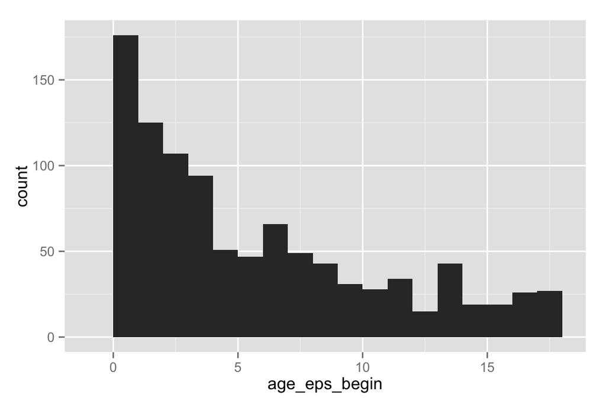

```r
#looking at age of child at episode begin
require(ggplot2)
ggplot(dat, aes(x=age_eps_begin)) +
  geom_histogram(binwidth = 1)
```

# A practical example - Choose a counterfactual $x_c$.

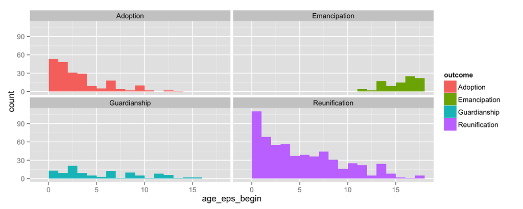

```r
#looking at age of child at episode begin by outcome
ggplot(dat, aes(x=age_eps_begin, fill=outcome)) +
  geom_histogram(binwidth = 1) +
  facet_wrap(~ outcome)
```

# A practical example - Estimate a model.

## Need to estimate a statistical model to get

1. A vector of parameters $\hat{\boldsymbol\beta}$, and
2. The associated variance-covariance matrix, $\hat{\boldsymbol V}$.

# A practical example - Estimate a model.

## Prep the data

```r
# easy to load external packages
# install.packages("nnet") # install once
require(nnet)             # load every time

# recode data
levels(dat$outcome) <- c("Adoption", "Emancipation"
                         ,"Guardianship", "Reunification")

# relevel our outcome variable
dat$outcome_rl <- relevel(dat$outcome
                          , ref = "Emancipation")

# recode to numeric
dat$outcome_rl <- as.numeric(dat$outcome_rl)
```

# A practical example - Estimate a model.

## Run the model

```r
# run the multinomial model
model <- multinom(outcome_rl ~ age_eps_begin +
                   eps_rank
                 ,data = dat
                 ,Hess = TRUE)
```

# A practical example - Estimate a model.

## Display of summary the model

```r
model
```

```
## Call:
## multinom(formula = outcome_rl ~ age_eps_begin + eps_rank, data = dat,
##     Hess = TRUE)
##
## Coefficients:
##   (Intercept) age_eps_begin    eps_rank
## 2   11.457365    -1.0280750 -0.10995325
## 3    9.797665    -0.8393067  0.05195097
## 4   11.597181    -0.8691345  0.07149574
##
## Residual Deviance: 1720.749
## AIC: 1738.749
```

# A practical example - Estimate a model.

## Extract a vector of parameters $\hat{\boldsymbol\beta}$

```r
#run the multinomial model
pe <- model$wts[c(6,7,8,10,11,12,14,15,16)]
pe[1:3]
```

```
## [1] 11.4573653 -1.0280750 -0.1099532
```

```r
pe[4:6]
```

```
## [1]  9.79766546 -0.83930667  0.05195097
```

```r
pe[7:9]
```

```
## [1] 11.59718150 -0.86913446  0.07149574
```

# A practical example - Estimate a model.

## Extract the associated variance-covariance matrix, $\hat{\boldsymbol V}$

```r
#run the multinomial model
vc <- solve(model$Hess)
```

# A practical example - Draw several $\tilde{\boldsymbol\beta}$ from $\mathcal{N}(\hat{\boldsymbol\beta},\,\hat{\boldsymbol V})$.

```r
#load a package which contains a multivariate normal
#sampling function
require(MASS)
#assign a variable for the number of simulations
sims <- 10000
#draw the indicates number of beta simulates
#using our extracted model data
simbetas <- mvrnorm(sims,pe,vc)
```

# A practical example - Last two steps…

- Calculate expected values for all of your draws from $\mathcal{N}$, and
- Calculate summary statistics for each level of $x_c$.
- Specific calculations are beyond the scope of this presentation
- But the `simcf` package from Chris Adolph (political scientist at the University of Washington) will do them for us!

# A practical example - Last two steps

## Get data read for `simcf`

- Re-arrange simulates to array format

```r
simb <- array(NA, dim = c(sims,3,3))
simb[,,1] <- simbetas[,1:3]
simb[,,2] <- simbetas[,4:6]
simb[,,3] <- simbetas[,7:9]
```

- Specify range of counterfactual values

```r
agerange <- seq(0,17,by=0.1)
```

# A practical example - Last two steps

## Get data read for `simcf`

- Load `simcf` and use the `cfFactorial()` function to set specific values for simulation.

```r
require(simcf)
xhyp <- cfFactorial(age = agerange
                    ,ep_rank = mean(dat$eps_rank))
```

- Run the simulation (this is where the last two steps are really performed).

```r
test_sims <- mlogitsimev(xhyp,simb,ci=0.95)
```

# Get the data ready to graph

```r
y <- as.vector(test_sims$pe[,1:4])

x <- rep(1:length(agerange), 4)

lower <- as.vector(test_sims$lower[,1:4,])

upper <- as.vector(test_sims$upper[,1:4,])

Outcome <- c(rep("Adoption", length(agerange))
                 ,rep("Guardianship"
                      ,length(agerange))
                 ,rep("Reunification"
                      ,length(agerange))
                 ,rep("Emancipation"
                      ,length(agerange)))
```

# Get the data ready to graph

```r
dat_sim_plot <- data.frame(y,x,lower,upper,Outcome)
```

# Graph the data!

```r
p1 <- ggplot(dat_sim_plot
       ,aes(x=x/10, y=y, group=Outcome)) +
        geom_line()
```

# Graph the data!

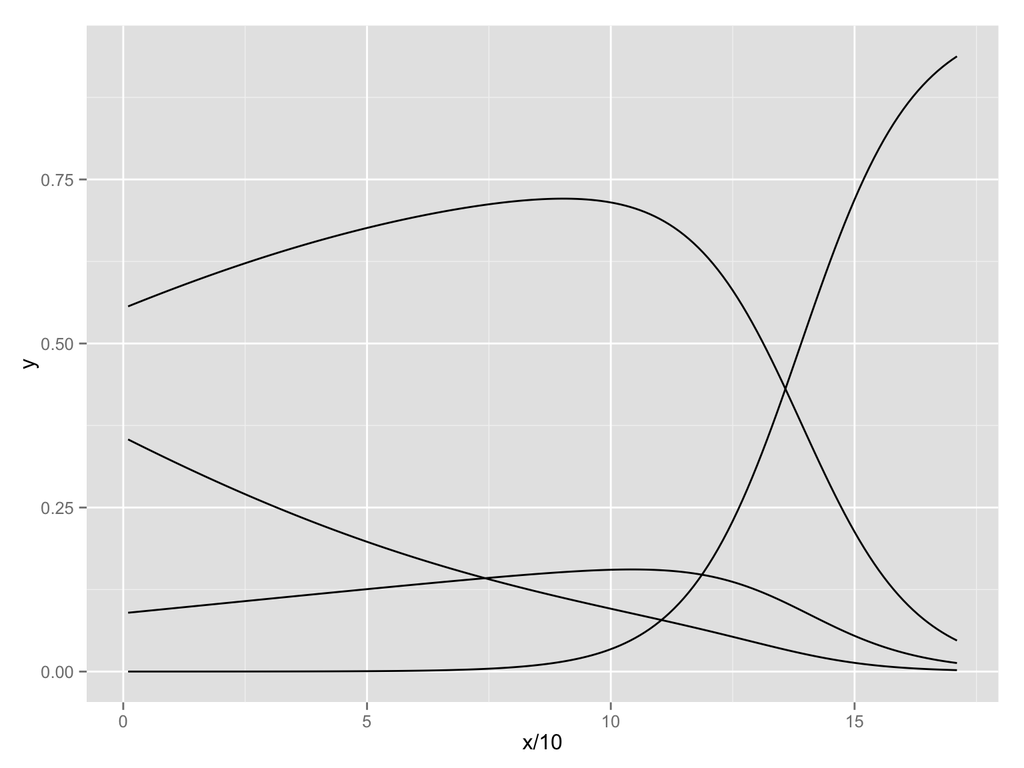

# Make it Pretty!

```r
p2 <- ggplot(dat_sim_plot
       ,aes(x=x/10, y=y, group=Outcome)) +
        geom_line(size=1, alpha=.5) +
        geom_ribbon(aes(ymin=lower
                        ,ymax=upper
                        ,fill=Outcome), alpha=.5) +
        ylab("Pr(Outcome|Age,Prior Episodes)") +
        xlab("Age at Entry into Foster Care") +
        theme_bw()
```

# Make it Pretty

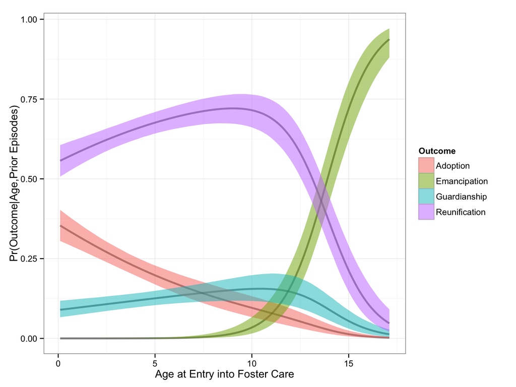